# Automatisieren von Fehlerrechnung

$\sigma_{f(x_i)} = \sqrt{\sum_{i=1}^m \left( \frac{\partial f}{\partial x_i}\right)^{\!2} \sigma_{x_i}^2}$

- Gesucht: Fehler von $f(x_i)$, wenn $x_i$ Fehler haben
- Manuelle Fehlerfortpflanzung:
1. Berechne die Ableitungen von $f$ nach allen fehlerbehafteten Größen $x_i$
2. Ableitungen in die obere Formel einsetzen
3. Werte und Fehler der $x_i$ einsetzen
- Probleme:
- Kompliziert, dauert lange, man macht oft Fehler
- Falsches Ergebnis, wenn $x_i$ korreliert sind

$\operatorname{cov}(\vec{f}) = \mathbf{J} \operatorname{cov}(\vec{x}) \mathbf{J}^\top$

$\mathbf{J}$ ist Jacobimatrix von $\vec{f}$ nach $\vec{x}$.

## `uncertainties`

- Erlaubt es, Fehlerrechnung automatisch durchzuführen
- Datentyp: `ufloat`, repräsentiert Wert mit Fehler

```python
from uncertainties import ufloat

x = ufloat(5, 1)
y = ufloat(3, 1)

x + y
```

```
8.0+/-1.4142135623730951
```

```python
# Korrelationen werden von uncertainties beachtet:
x = ufloat(3, 1)
y = ufloat(3, 1)

print(x**2 - y)
print(x**2 - x) # Fehler ist kleiner!
```

```
6.0+/-6.1
6.0+/-5.0
```

`uncertainties.unumpy` ergänzt numpy:

```python
import numpy as np
import uncertainties.unumpy as unp

x = [1, 2, 3, 4, 5]
err = [0.1, 0.3, 0.1, 0.8, 1.0]

y = unp.uarray(x, err)

unp.cos(unp.exp(y))
```

```
array([-0.9117339147869651+/-0.11166193174450133,
       0.4483562418187328+/-1.9814233218473645,
       0.3285947554325321+/-1.8970207322669204,
       -0.3706617333977958+/-40.567208903209576,
       -0.7260031145123346+/-102.06245489729305], dtype=object)
```

Zugriff auf Wert und Standardabweichung mit `n` und `s`:

```python
x = ufloat(5, 1)
print(x.n)
print(x.s)
```

```
5.0
1.0
```

Bei `unumpy` mit `nominal_values` und `std_devs`

```python
x = unp.uarray([1, 2, 3], [0.3, 0.3, 0.1])
print(unp.nominal_values(x))
print(unp.std_devs(x))
```

```
[ 1.  2.  3.]
[ 0.3  0.3  0.1]
```

Kann man natürlich auch abkürzen:

```python
from uncertainties.unumpy import (nominal_values as noms,
                                  std_devs as stds)

print(noms(x))
print(stds(x))
```

```
[ 1.  2.  3.]
[ 0.3  0.3  0.1]
```

Man muss daran denken, die Funktionen aus unumpy zu benutzen (`exp`, `cos`, etc.)

```python
unp.cos(x)
```

```
array([0.5403023058681398+/-0.25244129544236893,
       -0.4161468365471424+/-0.2727892280477045,
       -0.9899924966004454+/-0.014112000805986721], dtype=object)
```

# korrelierte Werte

```python
from uncertainties import correlated_values

values = [1, 2]

cov = [[0.5, 0.25],
       [0.25, 0.2]]

x, y = correlated_values(values, cov)
```

### Vorsicht bei Fits:

korrelierte Fit-Parameter führen zu nichts-sagenden Ergebnissen. Kontrolle: Kovarianzmatrix.

```
0.42+/-0.06
2.10+/-0.07

[[ 0.00311356 -0.00406271]
 [-0.00406271  0.00539254]]
```

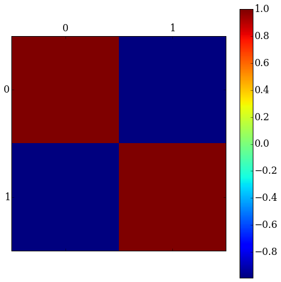

```python
%matplotlib inline

from numpy.random import normal
import numpy as np
import matplotlib.pyplot as plt
plt.rcParams['figure.figsize'] = (10, 8)
plt.rcParams['font.size'] = 16
from scipy.optimize import curve_fit
from uncertainties import correlated_values, correlation_matrix

def f1(x, a, b):
    return a * np.exp(b * x)

def f2(x, a, b, c):
    return a * np.exp(b * x + c)

x = np.linspace(0, 2, 30)
y = 0.5 * np.exp(2 * x) + normal(0, 1, 30)


params, cov = curve_fit(f1, x, y)
#params, cov = curve_fit(f2, x, y)

params = correlated_values(params, cov)

for param in params:
    print(param)
print()
print(cov)

plt.matshow(correlation_matrix(params))
plt.colorbar()
```

## Vorsicht

Man kann keine `ufloat`s plotten:

```
<Container object of 3 artists>
```

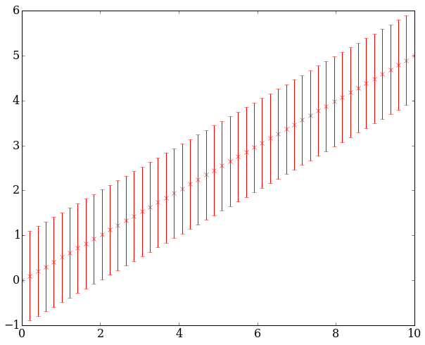

```python
x = np.linspace(0, 10)
y = unp.uarray(np.linspace(0, 5), 1)

#plt.plot(x, y, 'rx')
plt.errorbar(x, unp.nominal_values(y), yerr=unp.std_devs(y), fmt='rx')
```

# Sympy

- Problem: Die Assistenten möchten aber trotzdem, dass man alle Ableitungen in das Protokoll schreibt
- Lösung: Ableitungen automatisch generieren

SymPy importieren:

```python
import sympy
```

Mathematische Variablen erzeugen mit `var()`:

```python
x, y, z = sympy.var('x y z')

x + y + z
```

```
x + y + z
```

Differenzieren mit `diff()`:

```python
f = x + y**3 - sympy.cos(z)**2

print(f.diff(x))
print(f.diff(y))
print(f.diff(z))
print(f.diff(z, z, z))
```

```
1
3*y**2
2*sin(z)*cos(z)
-8*sin(z)*cos(z)
```

Eine Funktion, die automatisch die Fehlerformel generiert:

```python
import sympy

def error(f, err_vars=None):
    from sympy import Symbol, latex
    s = 0
    latex_names = dict()

    if err_vars == None:
        err_vars = f.free_symbols

    for v in err_vars:
        err = Symbol('latex_std_' + v.name)
        s += f.diff(v)**2 * err**2
        latex_names[err] = '\\sigma_{' + latex(v) + '}'

    return latex(sympy.sqrt(s), symbol_names=latex_names)

E, q, r = sympy.var('E_x q r')

f = E + q**2 * r

print(error(f))
```

```
\sqrt{\sigma_{E_{x}}^{2} + 4 \sigma_{q}^{2} q^{2} r^{2} + \sigma_{r}^{2} q^{4}}
```

$\sqrt{\sigma_{E_{x}}^{2} + 4 \sigma_{q}^{2} q^{2} r^{2} + \sigma_{r}^{2} q^{4}}$